# Descriptive Statistics

# Overview

For this portion of the project, we are calculating Changes in Median Home Value and Neighborhood Metrics, from 2000 to 2010.

# Packages Used

```r
library( dplyr )
library( knitr )
library( pander )
library(bannerCommenter)
library( stargazer )
library( here )
library( scales )
library( ggplot2 )
library( ggthemes )
library( gridExtra )
set.seed( 1234 )
s.type <- "text"
```

# Data

For this project, we are using data from the [Longitudinal Tabulated Database (LTDB)](https://s4.ad.brown.edu/projects/diversity/Researcher/Bridging.htm)

## Load and Merge Data

The first step is to download data for the years 2000 and 2010 along with their metadata and combine them into one dataset.

```r
d1 <- readRDS( "C:/Users/rduran3/Desktop/data/rodeo/LTDB-2000.rds" )
d2 <- readRDS( "C:/Users/rduran3/Desktop/data/rodeo/LTDB-2010.rds" )
md <- readRDS( "C:/Users/rduran3/Desktop/data/rodeo/LTDB-META-DATA.rds" )

d1 <- select( d1, - year )
d2 <- select( d2, - year )

d <- merge( d1, d2, by="tractid" )
d <- merge( d, md, by="tractid" )
```

## Add Federal Data

We will be pulling federal data for the [New Market Tax Credit (NMTC)](https://www.cdfifund.gov/news-events/news/Pages/news-detail.aspx?NewsID=364&Category=Press%20Releases) and [Low-Income Housing Tax Credit (LIHTC)](https://lihtc.huduser.gov/) prgrams to our dataset.

```r
# New Market Tax Credit (NMTC) Data
URL1 <- "https://raw.githubusercontent.com/DS4PS/cpp-528-spr-2020/master/labs/data/raw/NMTC/nmtc-sheet-01.csv"
nmtc <- read.csv( URL1, stringsAsFactors=F )

# Low-Income Housing Tax Credit (LIHTC) Data
URL <- "https://raw.githubusercontent.com/DS4PS/cpp-528-spr-2020/master/labs/data/raw/LIHTC/LIHTCPUB.csv"
lihtc <- read.csv( URL, stringsAsFactors=F )

# remove anything not a number from the string
d$id2 <- gsub( "[^0-9]", "", d$tractid )

# fix IDs so they are match
d$id2 <- as.numeric( d$id2 )
```

## Aggregate Federal Data

Since there are multiple projects per Census tract, we need to aggregate the project data before merging into our primary dataset.

```r
# LIHTC:
lihtc.dollars <-
  lihtc %>%
  filter( yr_alloc >= 2000 & yr_alloc <= 2010 ) %>%
  group_by( fips2010 ) %>%
  summarize( num.lihtc = n(), lihtc.total = sum( allocamt, na.rm=T ) )

# NMTC:
# remove dollar sign and commas
nmtc$amount <- gsub( "[,$]", "", nmtc$QLICI.Amount )
# convert characters to numeric
nmtc$amount <- as.numeric( nmtc$amount ) %>% round(0)

nmtc.dollars <-
  nmtc %>%
  filter( Origination.Year >= 2000 & Origination.Year <= 2010 ) %>%
  group_by( X2010.Census.Tract ) %>%
  summarize( num.nmtc=n(), nmtc.total = sum( amount, na.rm=T ) )
```

## Merge Census and Tax Policy Data

Now with the data agrigated we are able to merge into our Primary dataset.

```r
# Merge Datasets
d <- merge( d, nmtc.dollars, by.x="id2", by.y="X2010.Census.Tract", all.x=T )
d <- merge( d, lihtc.dollars, by.x="id2", by.y="fips2010", all.x=T )

# recode tracts that had no grants from NA to 0

d$num.nmtc[ is.na(d$num.nmtc) ] <- 0
d$nmtc.total[ is.na(d$nmtc.total) ] <- 0

d$num.lihtc[ is.na(d$num.lihtc) ] <- 0
d$lihtc.total[ is.na(d$lihtc.total) ] <- 0
```

## Filter for Urban Cities

Again, we were interested in only urban areas, we omitted rural areas by filtering only urban tracts. We also omitted non-numeric values. We will also back-up our dataset.

```r
d <- filter( d, urban == "urban" )
d.full <- d
d <- d.full
```

## Creating New Variables

Now we we have formatted our dataset, we can repeat the variable creation steps from [Part 1.2: Descriptive Analysis of Neighborhood Change](https://r-class.github.io/cpp-528-spr-2020-group-01/report-templates/2b-descriptive-analysis-of-neighborhood-change.html) to examine the impact of the tax policies.

```r
# adjust 2000 home values for inflation
mhv.00 <- d$mhmval00 * 1.28855
mhv.10 <- d$mhmval12
# Median Home Value change ($) from 2000 to 2010
mhv.change <- mhv.10 - mhv.00
# Fliter out home values less than 10k
mhv.00[ mhv.00 < 1000 ] <- NA
# Median Home Value change ($) from 2000 to 2010
mhv.growth <- 100 * ( mhv.change / mhv.00 )
mhv.growth[ mhv.growth > 200 ] <- NA
# Adding Variables back into Dataset
d$mhv.00 <- mhv.00
d$mhv.10 <- mhv.10
d$mhv.change <- mhv.change
d$mhv.growth <- mhv.growth
#Calculating new proportion variables from existing variables.

# Keep only variables we need
d <- select( d,
             tractid, cbsa, cbsaname,            # ids / units of analysis
             mhv.00, mhv.10, mhv.change, mhv.growth,    # home value
             hinc00, hu00, own00, rent00,        # ses
             hinc12, hu10, own10, rent10,
             empclf00, clf00, unemp00, prof00,   # employment
             empclf12, clf12, unemp12, prof12,
             dpov00, npov00,                     # poverty
             dpov12, npov12,
             ag25up00, hs00, col00,              # education
             ag25up12, hs12, col12,
             pop00.x, nhwht00, nhblk00, hisp00, asian00,   # race
             pop10, nhwht10, nhblk10, hisp10, asian10,
             num.nmtc, nmtc.total,              # tax policy data
             num.lihtc, lihtc.total             # aggregated by census tract
          ) # end select
d <-
  d %>%
  mutate(
          # 2000 variables
          p.white.00 = 100 * nhwht00 / pop00.x,
          p.black.00 = 100 * nhblk00 / pop00.x,
          p.hisp.00 = 100 * hisp00 / pop00.x,
          p.asian.00 = 100 * asian00 / pop00.x,
          p.hs.edu.00 = 100 * (hs00+col00) / ag25up00,
          p.col.edu.00 = 100 * col00 / ag25up00,
          p.prof.00 = 100 * prof00 / empclf00,
          p.unemp.00 = 100 * unemp00 / clf00,
          pov.rate.00 = 100 * npov00 / dpov00,
          p.rent.00 = 100 * rent00 / hu00,
          # 2010 variables
          p.white.10 = 100 * nhwht10 / pop10,
          p.black.10 = 100 * nhblk10 / pop10,
          p.hisp.10 = 100 * hisp10 / pop10,
          p.asian.10 = 100 * asian10 / pop10,
          p.hs.edu.10 = 100 * (hs12+col12) / ag25up12,
          p.col.edu.10 = 100 * col12 / ag25up12,
          p.prof.10 = 100 * prof12 / empclf12,
          p.unemp.10 = 100 * unemp12 / clf12,
          pov.rate.10 = 100 * npov12 / dpov12,
          p.rent.10 = 100 * rent10 / hu10 )
# Calculate new variables using "group_by"
d <-
  d %>%
  group_by( tractid ) %>%
  mutate( metro.mhv.pct.00 = ntile( mhv.00, 100 ),
          metro.mhv.pct.10 = ntile( mhv.10, 100 ),
          metro.median.pay.00 = median( hinc00, na.rm=T ),
          metro.median.pay.10 = median( hinc12, na.rm=T ),
          metro.diversity.rank.00 = ntile( (100-p.white.00), 100 ),
          # metro total population 2000
          metro.pop.total.00 = sum( pop00.x, na.rm=T ),
          # metro total population 2010
          metro.pop.total.10 = sum( pop10, na.rm=T ),
          # tract rank in metro area for unemployment in 2000
          metro.unemp.rank.00 = ntile( p.unemp.00, 100 ),
          # tract rank in metro area for unemployment in 2010
          metro.unemp.rank.10 = ntile( p.unemp.10, 100 ) ) %>%
  ungroup() %>%
  mutate( metro.mhv.pct.change = metro.mhv.pct.10 - metro.mhv.pct.00,
          # metro population growth 2000-2010
          metro.pop.growth =
            ( metro.pop.total.10 - metro.pop.total.00 ) / metro.pop.total.00,
          metro.unemp.pct.change = metro.unemp.rank.10 - metro.unemp.rank.00,
          pay.change = metro.median.pay.10 - metro.median.pay.00,
          race.change = p.white.10 - p.white.00,
          pov.change = pov.rate.10 - pov.rate.00,
          p.unemp.change = p.unemp.10 - p.unemp.00,
          p.col.edu.change = p.col.edu.10 - p.col.edu.00,
          p.rent.change = p.rent.10 - p.rent.00)

# Create Dataset Backup
d.full2 <- d
d <- d.full2
```

# Discriptive Statistics for Tax Programs

## Total Tax Credit Distributions

```r
sum(d$num.nmtc)
```

```
## [1] 4778
```

```r
sum(d$nmtc.total)
```

```
## [1] 18384794962
```

```r
sum(d$num.lihtc)
```

```
## [1] 12625
```

```r
sum(d$lihtc.total)
```

```
## [1] 5620208334
```

# Comparing Recipient and Non-Recipient Tracts

Economic development investments target projects that have the greatest potential to succeed, so by design these investments are allocated to locations with “high need”.

NMTC projects target poor communities, so the “high need” tracts which recieved the investments differ from “low need” non-recipients.

The LIHTC program differs from NMTC in that affordable housing units can be built anywhere, so long as the rent cap requirement is met. In Practice these investments still tend to go to poor communities, since the rent cap is close to the rent they could have received anyways. Potential profit is not lost by setting a low rent cap in higher value areas.

In comparing recipiant and non-recipient tracts for both programs, we are able to determine the similarities and difference between both programs.

```r
# First we need to create a variable for recipient vs non-recipients tracts for both prograns:
# NMTC:
d$NMTC <- ifelse( d$num.nmtc > 0, "YES", "NO" )
# LIHTC:
d$LIHTC <- ifelse( d$num.lihtc > 0, "YES", "NO" )
# Now we can compare recipent and non-recipient tract for our variables of interest.
```

## Median Home Value

**In 2000:** For **NMTC recipient** tracts the average Tract Median Home Value was $146,649, while the median was $118,527.

For **LIHTC recipient** tracts the average Tract Median Home Value was $156,446, while the median was $126,407.

For **LIHTC non-recipient** tracts the average Tract Median Home Value was $192,005, while the median was $159,394.

```r
boxup("NMTC Recipient")
```

```
##
## ##----------------------------------------------------------------
## ##                        NMTC Recipient                         -
## ##----------------------------------------------------------------
```

```r
summary (d$mhv.00[ d$num.nmtc > 0 ], an.rm=T)
```

```
##    Min. 1st Qu.  Median    Mean 3rd Qu.    Max.    NA's
##   11167   79375  118527  146649  183393 1288551      24
```

```r
boxup("NMTC Non-Recipient")
```

```
##
## ##----------------------------------------------------------------
## ##                      NMTC Non-Recipient                       -
## ##----------------------------------------------------------------
```

```r
summary (d$mhv.00[ d$num.nmtc == 0 ], an.rm=T)
```

```
##    Min. 1st Qu.  Median    Mean 3rd Qu.    Max.    NA's
##    1280  106563  156043  188295  225328 1288551     173
```

```r
boxup("LIHTC Recipient")
```

```
##
## ##---------------------------------------------------------------
## ##                        LIHTC Recipient                       -
## ##---------------------------------------------------------------
```

```r
summary (d$mhv.00[ d$num.lihtc > 0 ], an.rm=T)
```

```
##    Min. 1st Qu.  Median    Mean 3rd Qu.    Max.    NA's
##    1280   89168  126407  156446  189288 1288551      33
```

```r
boxup("LIHTC Non-Recipient")
```

```
##
## ##---------------------------------------------------------------
## ##                      LIHTC Non-Recipient                     -
## ##---------------------------------------------------------------
```

```r
summary (d$mhv.00[ d$num.lihtc == 0 ], an.rm=T)
```

```
##    Min. 1st Qu.  Median    Mean 3rd Qu.    Max.    NA's
##    1506  108625  159394  192005  229970 1288551     164
```

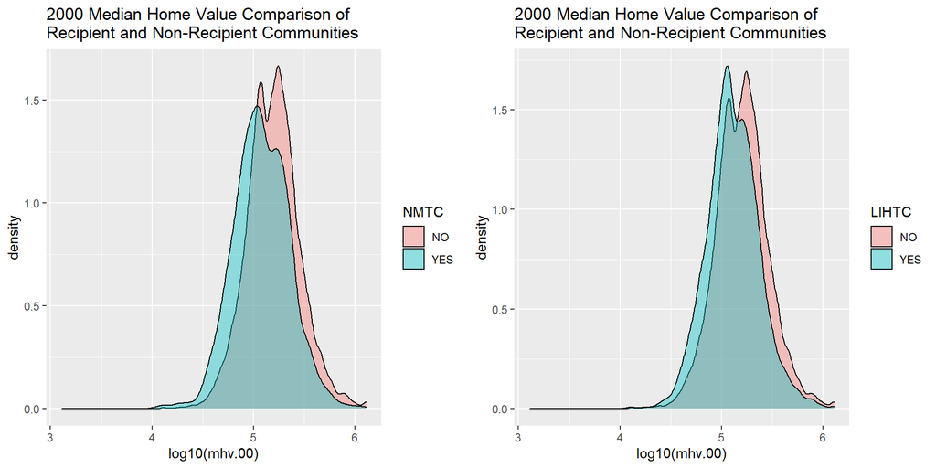

```r
plot3 <-
  ggplot( d, aes(x=log10(mhv.00), fill=NMTC )) +
  geom_density( alpha=0.4 ) +
  ggtitle("2000 Median Home Value Comparison of \nRecipient and Non-Recipient Communities")

plot4 <-
  ggplot( d, aes(x=log10(mhv.00), fill=LIHTC )) +
  geom_density( alpha=0.4 )  +
  ggtitle("2000 Median Home Value Comparison of \nRecipient and Non-Recipient Communities")

grid.arrange( plot3, plot4, nrow = 1 )
```

## Education Level

**In 2000:** For **NMTC recipient** tracts the average proportion of college graduates was 16.48%, while the median was 11.66%.

For **NMTC non-recipient** tracts the average proportion of college graduates was 25.94%, while the median was 21.45%.

For **LIHTC recipient** tracts the average proportion of college graduates was 19.43%, while the median was 15.22%.

For **LIHTC non-recipient** tracts the average proportion of college graduates was 26.67%, while the median was 22.23%.

```r
boxup("NMTC Recipient")
```

```
##
## ##----------------------------------------------------------------
## ##                        NMTC Recipient                         -
## ##----------------------------------------------------------------
```

```r
summary (d$p.col.edu.00[ d$num.nmtc > 0 ], an.rm=T)
```

```
##    Min. 1st Qu.  Median    Mean 3rd Qu.    Max.    NA's
##   0.000   7.095  11.664  16.482  20.152 100.000       2
```

```r
boxup("NMTC Non-Recipient")
```

```
##
## ##----------------------------------------------------------------
## ##                      NMTC Non-Recipient                       -
## ##----------------------------------------------------------------
```

```r
summary (d$p.col.edu.00[ d$num.nmtc == 0 ], an.rm=T)
```

```
##    Min. 1st Qu.  Median    Mean 3rd Qu.    Max.    NA's
##    0.00   12.13   21.45   25.94   36.20  100.00     152
```

```r
boxup("LIHTC Recipient")
```

```
##
## ##---------------------------------------------------------------
## ##                        LIHTC Recipient                       -
## ##---------------------------------------------------------------
```

```r
summary (d$p.col.edu.00[ d$num.lihtc > 0 ], an.rm=T)
```

```
##    Min. 1st Qu.  Median    Mean 3rd Qu.    Max.    NA's
##   0.000   8.712  15.218  19.432  26.194  87.701       4
```

```r
boxup("LIHTC Non-Recipient")
```

```
##
## ##---------------------------------------------------------------
## ##                      LIHTC Non-Recipient                     -
## ##---------------------------------------------------------------
```

```r
summary (d$p.col.edu.00[ d$num.lihtc == 0 ], an.rm=T)
```

```
##    Min. 1st Qu.  Median    Mean 3rd Qu.    Max.    NA's
##    0.00   12.59   22.23   26.67   37.31  100.00     150
```

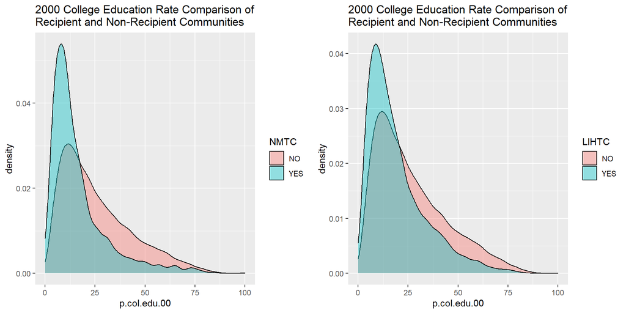

```r
plot1 <-
  ggplot( d, aes(x=p.col.edu.00, fill=NMTC )) +
  geom_density(alpha=0.4) +
  ggtitle("2000 College Education Rate Comparison of \nRecipient and Non-Recipient Communities")

plot2 <-
  ggplot( d, aes(x=p.col.edu.00, fill=LIHTC)) +
  geom_density(alpha=0.4) +
  ggtitle("2000 College Education Rate Comparison of \nRecipient and Non-Recipient Communities")

grid.arrange( plot1, plot2, nrow = 1 )
```

## Poverty Rate

**In 2000:** For **NMTC recipient** tracts the average poverty rate was 27.49%, while the median was 26.13%.

For **NMTC non-recipient** tracts the average poverty rate was 11.97%, while the median was 8.24%.

For **LIHTC recipient** tracts the average poverty rate was 19.44%, while the median was 15.92%.

For **LIHTC non-recipient** tracts the average poverty rate was 11.29%, while the median was 7.79%.

```r
boxup("NMTC Recipient")
```

```
##
## ##----------------------------------------------------------------
## ##                        NMTC Recipient                         -
## ##----------------------------------------------------------------
```

```r
summary (d$pov.rate.00[ d$num.nmtc > 0 ], an.rm=T)
```

```
##    Min. 1st Qu.  Median    Mean 3rd Qu.    Max.    NA's
##    0.00   17.79   26.13   27.49   35.14   93.17       3
```

```r
boxup("NMTC Non-Recipient")
```

```
##
## ##----------------------------------------------------------------
## ##                      NMTC Non-Recipient                       -
## ##----------------------------------------------------------------
```

```r
summary (d$pov.rate.00[ d$num.nmtc == 0 ], an.rm=T)
```

```
##    Min. 1st Qu.  Median    Mean 3rd Qu.    Max.    NA's
##   0.000   4.335   8.240  11.973  15.835 100.000     185
```

```r
boxup("LIHTC Recipient")
```

```
##
## ##---------------------------------------------------------------
## ##                        LIHTC Recipient                       -
## ##---------------------------------------------------------------
```

```r
summary (d$pov.rate.00[ d$num.lihtc > 0 ], an.rm=T)
```

```
##    Min. 1st Qu.  Median    Mean 3rd Qu.    Max.    NA's
##   0.000   7.989  15.919  19.440  28.628  88.210       6
```

```r
boxup("LIHTC Non-Recipient")
```

```
##
## ##---------------------------------------------------------------
## ##                      LIHTC Non-Recipient                     -
## ##---------------------------------------------------------------
```

```r
summary (d$pov.rate.00[ d$num.lihtc == 0 ], an.rm=T)
```

```
##    Min. 1st Qu.  Median    Mean 3rd Qu.    Max.    NA's
##   0.000   4.145   7.785  11.293  14.768 100.000     182
```

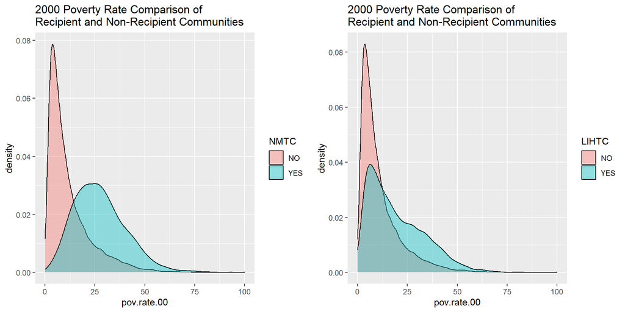

```r
plot1 <-
  ggplot( d, aes(x=pov.rate.00, fill=NMTC )) +
  geom_density(alpha=0.4) +
  ggtitle("2000 Poverty Rate Comparison of \nRecipient and Non-Recipient Communities")

plot2 <-
  ggplot( d, aes(x=pov.rate.00, fill=LIHTC)) +
  geom_density(alpha=0.4) +
  ggtitle("2000 Poverty Rate Comparison of \nRecipient and Non-Recipient Communities")

grid.arrange( plot1, plot2, nrow = 1 )
```

## Unemployment Rate

**In 2000:** For **NMTC recipient** tracts the average unemployment rate was 12.04%, while the median was 10.21%.

For **NMTC non-recipient** tracts the average unemployment rate was 6.06%, while the median was 4.50%.

For **LIHTC recipient** tracts the average unemployment rate was 8.75%, while the median was 6.60%.

For **LIHTC non-recipient** tracts the average unemployment rate was 5.83%, while the median was 4.38%.

```r
boxup("NMTC Recipient")
```

```
##
## ##----------------------------------------------------------------
## ##                        NMTC Recipient                         -
## ##----------------------------------------------------------------
```

```r
summary (d$p.unemp.00[ d$num.nmtc > 0 ], an.rm=T)
```

```
##    Min. 1st Qu.  Median    Mean 3rd Qu.    Max.    NA's
##   0.000   6.548  10.219  12.041  14.966  93.683       3
```

```r
boxup("NMTC Non-Recipient")
```

```
##
## ##----------------------------------------------------------------
## ##                      NMTC Non-Recipient                       -
## ##----------------------------------------------------------------
```

```r
summary (d$p.unemp.00[ d$num.nmtc == 0 ], an.rm=T)
```

```
##    Min. 1st Qu.  Median    Mean 3rd Qu.    Max.    NA's
##   0.000   2.919   4.504   6.061   7.338 100.000     182
```

```r
boxup("LIHTC Recipient")
```

```
##
## ##---------------------------------------------------------------
## ##                        LIHTC Recipient                       -
## ##---------------------------------------------------------------
```

```r
summary (d$p.unemp.00[ d$num.lihtc > 0 ], an.rm=T)
```

```
##    Min. 1st Qu.  Median    Mean 3rd Qu.    Max.    NA's
##   0.000   3.964   6.602   8.745  11.459  78.189       6
```

```r
boxup("LIHTC Non-Recipient")
```

```
##
## ##---------------------------------------------------------------
## ##                      LIHTC Non-Recipient                     -
## ##---------------------------------------------------------------
```

```r
summary (d$p.unemp.00[ d$num.lihtc == 0 ], an.rm=T)
```

```
##    Min. 1st Qu.  Median    Mean 3rd Qu.    Max.    NA's
##   0.000   2.860   4.382   5.830   7.038 100.000     179
```

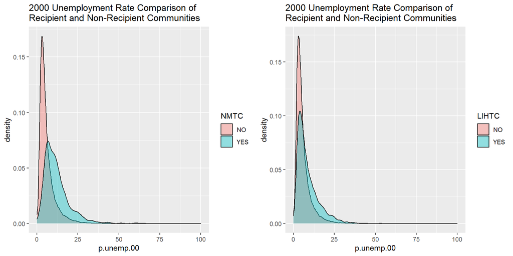

```r
plot1 <-
  ggplot( d, aes(x=p.unemp.00, fill=NMTC )) +
  geom_density(alpha=0.4) +
  ggtitle("2000 Unemployment Rate Comparison of \nRecipient and Non-Recipient Communities")

plot2 <-
  ggplot( d, aes(x=p.unemp.00, fill=LIHTC)) +
  geom_density(alpha=0.4) +
  ggtitle("2000 Unemployment Rate Comparison of \nRecipient and Non-Recipient Communities")

grid.arrange( plot1, plot2, nrow = 1 )
```

## Proportion Renters

**In 2000:** For **NMTC recipient** tracts the average proportion of renters was 57.14%, while the median was 58.27%.

For **NMTC non-recipient** tracts the average proportion of renters was 31.76%, while the median was 26.70%.

For **LIHTC recipient** tracts the average proportion of renters was 44.19%, while the median was 42.03%.

For **LIHTC non-recipient** tracts the average proportion of renters was 30.61%, while the median was 25.19%.

```r
boxup("NMTC Recipient")
```

```
##
## ##----------------------------------------------------------------
## ##                        NMTC Recipient                         -
## ##----------------------------------------------------------------
```

```r
summary (d$p.rent.00[ d$num.nmtc > 0 ], an.rm=T)
```

```
##    Min. 1st Qu.  Median    Mean 3rd Qu.    Max.    NA's
##   2.284  42.538  58.267  57.137  72.285 100.000       2
```

```r
boxup("NMTC Non-Recipient")
```

```
##
## ##----------------------------------------------------------------
## ##                      NMTC Non-Recipient                       -
## ##----------------------------------------------------------------
```

```r
summary (d$p.rent.00[ d$num.nmtc == 0 ], an.rm=T)
```

```
##    Min. 1st Qu.  Median    Mean 3rd Qu.    Max.    NA's
##    0.00   14.25   26.70   31.76   45.13  100.00     146
```

```r
boxup("LIHTC Recipient")
```

```
##
## ##---------------------------------------------------------------
## ##                        LIHTC Recipient                       -
## ##---------------------------------------------------------------
```

```r
summary (d$p.rent.00[ d$num.lihtc > 0 ], an.rm=T)
```

```
##     Min.  1st Qu.   Median     Mean  3rd Qu.     Max.     NA's
##   0.6347  26.3665  42.0301  44.1853  60.1907 100.0000        4
```

```r
boxup("LIHTC Non-Recipient")
```

```
##
## ##---------------------------------------------------------------
## ##                      LIHTC Non-Recipient                     -
## ##---------------------------------------------------------------
```

```r
summary (d$p.rent.00[ d$num.lihtc == 0 ], an.rm=T)
```

```
##    Min. 1st Qu.  Median    Mean 3rd Qu.    Max.    NA's
##    0.00   13.48   25.19   30.61   43.48  100.00     144
```

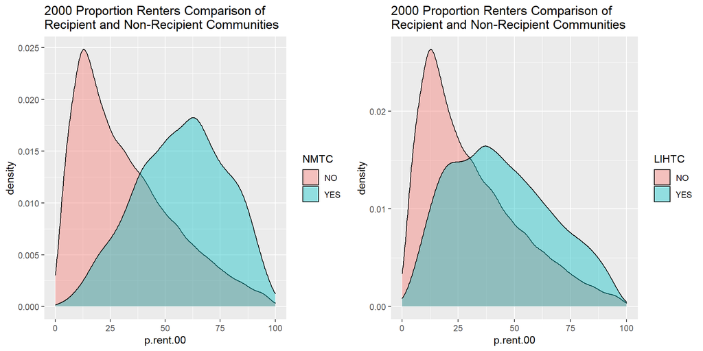

```r
plot1 <-
  ggplot( d, aes(x=p.rent.00, fill=NMTC )) +
  geom_density(alpha=0.4) +
  ggtitle("2000 Proportion Renters Comparison of \nRecipient and Non-Recipient Communities")

plot2 <-
  ggplot( d, aes(x=p.rent.00, fill=LIHTC)) +
  geom_density(alpha=0.4) +
  ggtitle("2000 Proportion Renters Comparison of \nRecipient and Non-Recipient Communities")

grid.arrange( plot1, plot2, nrow = 1 )
```

## Median Income

**In 2000:** For **NMTC recipient** tracts the average Tract Median Income was $27,688, while the median was $26,919.

For **NMTC non-recipient** tracts the average Tract Median Income was $48,244, while the median was $44,523.

For **LIHTC recipient** tracts the average Tract Median Income was $36,642, while the median was $33,697.

For **LIHTC non-recipient** tracts the average Tract Median Income was $49,413, while the median was $45,383.

```r
boxup("NMTC Recipient")
```

```
##
## ##----------------------------------------------------------------
## ##                        NMTC Recipient                         -
## ##----------------------------------------------------------------
```

```r
summary (d$metro.median.pay.00[ d$num.nmtc > 0 ], an.rm=T)
```

```
##    Min. 1st Qu.  Median    Mean 3rd Qu.    Max.
##    5663   20232   26919   27688   33483  167106
```

```r
boxup("NMTC Non-Recipient")
```

```
##
## ##----------------------------------------------------------------
## ##                      NMTC Non-Recipient                       -
## ##----------------------------------------------------------------
```

```r
summary (d$metro.median.pay.00[ d$num.nmtc == 0 ], an.rm=T)
```

```
##    Min. 1st Qu.  Median    Mean 3rd Qu.    Max.
##    2499   33712   44523   48244   58635  200001
```

```r
boxup("LIHTC Recipient")
```

```
##
## ##---------------------------------------------------------------
## ##                        LIHTC Recipient                       -
## ##---------------------------------------------------------------
```

```r
summary (d$metro.median.pay.00[ d$num.lihtc > 0 ], an.rm=T)
```

```
##    Min. 1st Qu.  Median    Mean 3rd Qu.    Max.
##    4621   24796   33697   36642   45752  189725
```

```r
boxup("LIHTC Non-Recipient")
```

```
##
## ##---------------------------------------------------------------
## ##                      LIHTC Non-Recipient                     -
## ##---------------------------------------------------------------
```

```r
summary (d$metro.median.pay.00[ d$num.lihtc == 0 ], an.rm=T)
```

```
##    Min. 1st Qu.  Median    Mean 3rd Qu.    Max.
##    2499   34890   45383   49413   60070  200001
```

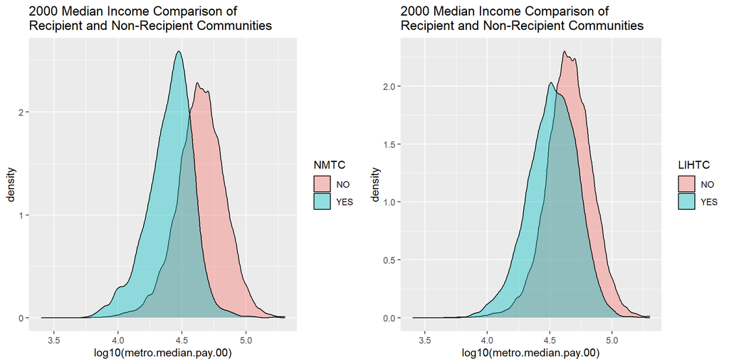

```r
plot3 <-
  ggplot( d, aes(x=log10(metro.median.pay.00), fill=NMTC )) +
  geom_density( alpha=0.4 ) +
  ggtitle("2000 Median Income Comparison of \nRecipient and Non-Recipient Communities")

plot4 <-
  ggplot( d, aes(x=log10(metro.median.pay.00), fill=LIHTC )) +
  geom_density( alpha=0.4 )  +
  ggtitle("2000 Median Income Comparison of \nRecipient and Non-Recipient Communities")

grid.arrange( plot3, plot4, nrow = 1 )
```

# Median Home Value Growth (%)

**In 2000:** For **NMTC recipient** tracts the average growth reate of Median Home Value was 39.60%, while the median was 33.36%.

For **NMTC non-recipient** tracts the average growth reate of Median Home Value was 29.18%, while the median was 24.83%.

For **LIHTC recipient** tracts the average growth reate of Median Home Value was 29.89%, while the median was 23.03%.

For **LIHTC non-recipient** tracts the average growth reate of Median Home Value was 29.40%, while the median was 25.33%.

```r
boxup("NMTC Recipient")
```

```
##
## ##----------------------------------------------------------------
## ##                        NMTC Recipient                         -
## ##----------------------------------------------------------------
```

```r
summary (d$mhv.growth[ d$num.nmtc > 0 ], an.rm=T)
```

```
##    Min. 1st Qu.  Median    Mean 3rd Qu.    Max.    NA's
##  -94.55   10.94   33.36   39.60   62.96  199.31      82
```

```r
boxup("NMTC Non-Recipient")
```

```
##
## ##----------------------------------------------------------------
## ##                      NMTC Non-Recipient                       -
## ##----------------------------------------------------------------
```

```r
summary (d$mhv.growth[ d$num.nmtc == 0 ], an.rm=T)
```

```
##    Min. 1st Qu.  Median    Mean 3rd Qu.    Max.    NA's
## -96.891   5.609  24.834  29.177  48.391 199.739     684
```

```r
boxup("LIHTC Recipient")
```

```
##
## ##---------------------------------------------------------------
## ##                        LIHTC Recipient                       -
## ##---------------------------------------------------------------
```

```r
summary (d$mhv.growth[ d$num.lihtc > 0 ], an.rm=T)
```

```
##    Min. 1st Qu.  Median    Mean 3rd Qu.    Max.    NA's
## -88.967   4.233  23.027  29.885  48.869 199.739     155
```

```r
boxup("LIHTC Non-Recipient")
```

```
##
## ##---------------------------------------------------------------
## ##                      LIHTC Non-Recipient                     -
## ##---------------------------------------------------------------
```

```r
summary (d$mhv.growth[ d$num.lihtc == 0 ], an.rm=T)
```

```
##    Min. 1st Qu.  Median    Mean 3rd Qu.    Max.    NA's
## -96.891   5.981  25.332  29.398  48.725 199.550     611
```

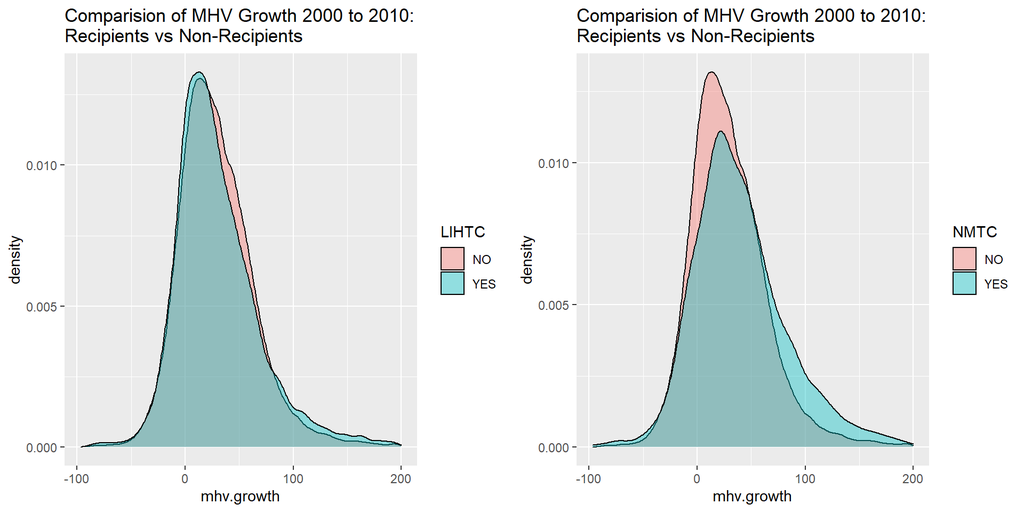

```r
p5 <-
  ggplot( d, aes(x=mhv.growth, fill=LIHTC )) +
  geom_density( alpha=0.4 )  +
  ggtitle("Comparision of MHV Growth 2000 to 2010: \nRecipients vs Non-Recipients")

p6 <-
ggplot( d, aes(x=mhv.growth, fill=NMTC )) +
  geom_density( alpha=0.4 )  +
  ggtitle("Comparision of MHV Growth 2000 to 2010: \nRecipients vs Non-Recipients")

grid.arrange( p5, p6, nrow = 1 )
```

# References

[Community Development Financial Institutions Fund. (2019). CDFI Fund releases summary report and public data for NMTC program for FYs 2003-2017. U.S. Department of the Treasury. (April 30, 2020). https://www.cdfifund.gov/news-events/news/Pages/news-detail.aspx?NewsID=364&Category=Press%20Releases](https://www.cdfifund.gov/news-events/news/Pages/news-detail.aspx?NewsID=364&Category=Press%20Releases)

[Data Sciences for Public Service. (2020). Data Sciences III: Lab 06 tutorial. Arizona State University MS in Program Evaluation & Data Analytics. (April 26, 2020). https://ds4ps.org/cpp-528-spr-2020/labs/lab-06-tutorial.html](https://ds4ps.org/cpp-528-spr-2020/labs/lab-06-tutorial.html)

[U.S. Department of Housing and Urban Development. (2019). LIHTC database access. U.S. Department of Housing and Urban Development.. (April 30, 2020). https://lihtc.huduser.gov/](https://lihtc.huduser.gov/)

Novogradac Company LLP. (2016). About the LIHTC. Novogradac Company LLP. (April 30, 2020). www.novoco.com/resource-centers/affordable-housing-tax-credits/lihtc-basics/about-lihtc

Analysis Created By: Group 1: Ricky Duran, Jason Eastman, & Katie Gantry For: CPP 528 - Data Sciences for Public Service III (Spring 2020) Created On: “May 01, 2020”